# Nick’s Gene Expression Network Analysis

Christof Seiler

August, 2016

This Rmd file contains a minimal network analysis pipeline using the packages `STRINGdb` and `BioNet`.

## Install Packages

Install necessary packages from bioconductor repository. Run this code only once to install packages.

```r
source("https://bioconductor.org/biocLite.R")
biocLite("STRINGdb")
biocLite("BioNet")
biocLite("DLBCL")
install.packages(c("stringr","igraph","visNetwork"))
```

Load packages.

```r
library(STRINGdb)
library(BioNet)
library(DLBCL)
library(stringr)
library(igraph)
library(visNetwork)
```

## Load Data

Load example dataset. Replace this with your own list of pvalues.

```r
diff_exp = read.csv("test_cases.csv")
# remove no test cases
excludeGenesFraction = sum(diff_exp$status == "NOTEST")/length(diff_exp$status)
excludeGenesFraction
```

```
## [1] 0
```

```r
diff_exp = diff_exp[!diff_exp$status == "NOTEST",]
# remove NAs in fold changes
foldChanges = as.numeric(as.character(diff_exp$log2.fold_change.))
diff_exp$log2.fold_change. = foldChanges
NAs = is.na(foldChanges)
diff_exp = diff_exp[!NAs,]
# remove Infs in fold changes
Infs = is.infinite(diff_exp$log2.fold_change.)
diff_exp = diff_exp[!Infs,]
dim(diff_exp)
```

```
## [1] 370  14
```

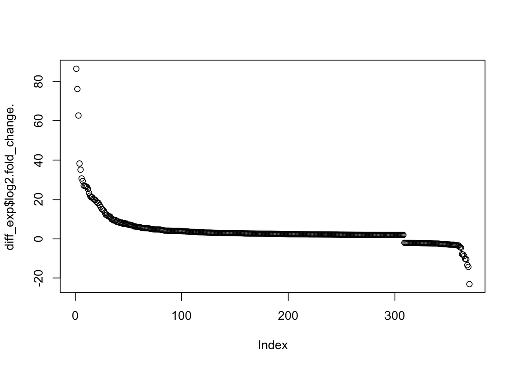

```r
plot(diff_exp$log2.fold_change.)
```

## Download Gene Network

Download proteins for human species (code is 9606).

Consider interaciton that are 0.9 confidence. From the STRING website:

In STRING, each protein-protein interaction is annotated with one or more ‘scores’. Importantly, these scores do not indicate the strength or the specificity of the interaction. Instead, they are indicators of confidence, i.e. how likely STRING judges an interaction to be true, given the available evidence. All scores rank from 0 to 1, with 1 being the highest possible confidence. A score of 0.5 would indicate that roughly every second interaction might be erroneous (i.e., a false positive).

```r
string_db = STRINGdb$new(version="10", species=9606, score_threshold=900, input_directory="")
```

Check how many proteins are in the database.

```r
string_proteins = string_db$get_proteins()
dim(string_proteins)
```

```
## [1] 20457     4
```

Map gene names to identifiers used in the database.

```r
mapped = string_db$map(diff_exp, "gene", removeUnmappedRows = FALSE)
interactions = string_db$get_interactions(mapped$STRING_id)
interactions = data.frame(from=interactions$from,to=interactions$to,combined_score=interactions$combined_score)
dim(interactions)
```

```
## [1] 432   3
```

```r
head(interactions)
```

```
##                   from                   to combined_score
## 1 9606.ENSP00000215631 9606.ENSP00000262345            900
## 2 9606.ENSP00000215631 9606.ENSP00000264260            908
## 3 9606.ENSP00000215794 9606.ENSP00000354394            992
## 4 9606.ENSP00000215794 9606.ENSP00000360869            977
## 5 9606.ENSP00000215794 9606.ENSP00000368699            999
## 6 9606.ENSP00000216341 9606.ENSP00000262345            906
```

## Find Subgraph

Fit a Beta-Uniform model.

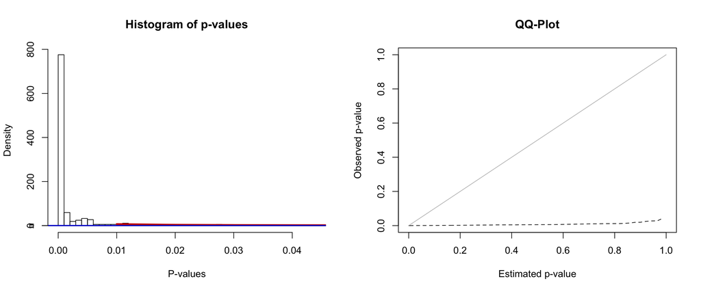

```r
pval = mapped$p_value
names(pval) = mapped$gene
fb = fitBumModel(pval)
```

```r
fb
```

```
## Beta-Uniform-Mixture (BUM) model
##
## 370 pvalues fitted
##
## Mixture parameter (lambda):  0.000
## shape parameter (a):         0.116
## log-likelihood:          2016.8
```

Set the `fdr` parameter which can be interpreted as the FDR of the subgraph. Smaller values will produce a smaller maximum subgraph. You should try a few values (e.g. 0.05, 0.01, 0.001, …) to obtain a reasonable small subgraph that permits biological interpretation.

First we make convert the interaction table into an igraph object and make the nodes names human readible.

```r
network = graph_from_data_frame(interactions)
revMappedNames = sapply(names(V(network)),
                        function(string_id)
                          paste(mapped[which(string_id == mapped$STRING_id),]$gene,collapse = "/")
                        )
V(network)$name = unlist(revMappedNames)
```

Then we search for the optimal subgraph.

```r
scores = scoreNodes(network, fb, fdr=0.005)
module = runFastHeinz(network, scores)
module
```

```
## IGRAPH DN-- 77 384 --
## + attr: name (v/c), score (v/n), combined_score (e/n)
## + edges (vertex names):
##  [1] GADD45B->IL12RB2 GADD45B->IL18RAP USP18  ->STAT1   USP18  ->IFIT1
##  [5] USP18  ->ISG15   GZMB   ->IL12RB2 GZMB   ->PRF1    GZMB   ->IL2RA
##  [9] NFKBIA ->EIF2AK2 NFKBIA ->ZBP1    TLR8   ->TLR7    OAS3   ->OASL
## [13] OAS3   ->PML     OAS3   ->ISG20   OAS3   ->STAT2   OAS3   ->IFITM1
## [17] OAS3   ->MX2     OAS3   ->OAS2    OAS3   ->IFI6    OAS3   ->SP100
## [21] OAS3   ->XAF1    OAS3   ->ADAR    OAS3   ->GBP2    OAS3   ->GBP1
## [25] OAS3   ->IFIT1   OAS3   ->IFIT3   OAS3   ->IFIT2   OAS3   ->ISG15
## [29] OAS3   ->IRF4    OAS3   ->MX1     OAS3   ->IFITM3  OAS3   ->IFITM2
## + ... omitted several edges
```

Differential expression between is coloured in red and green, where green shows an upregulation in the first condition and red an upregulation in second condition. The shape of the nodes depicts the score: rectangles indicate a negative score, circles a positive score.

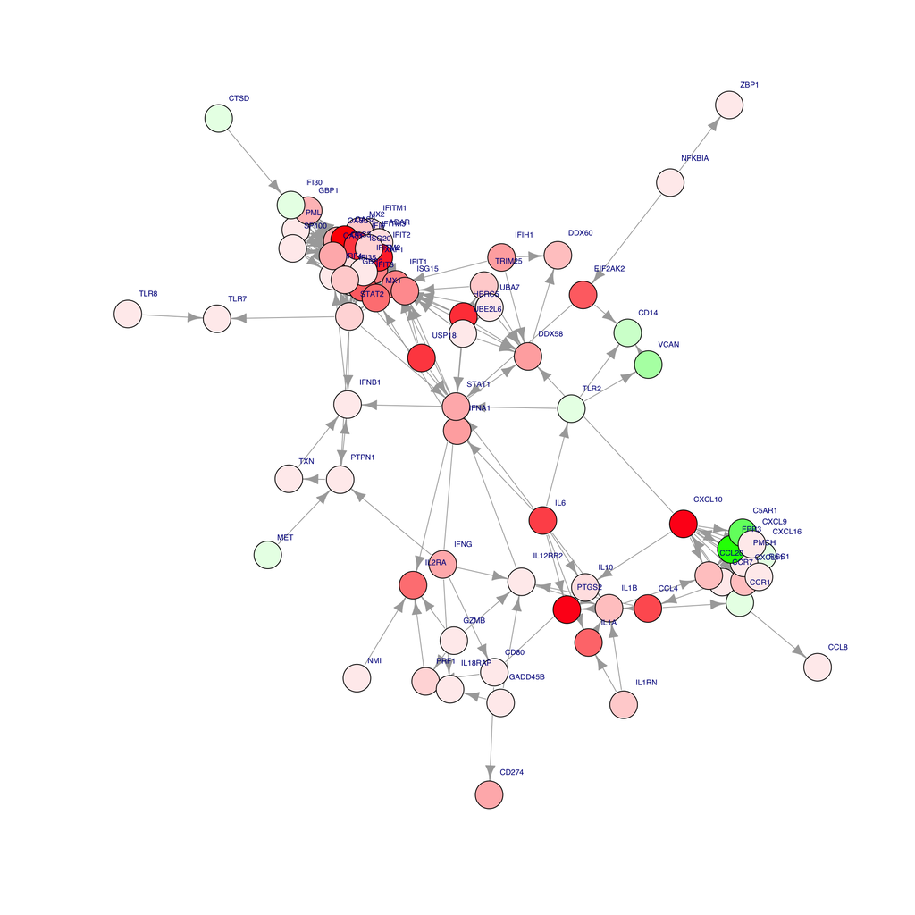

```r
par(mfrow=c(1,1))
logFC = na.omit(mapped$log2.fold_change.)
names(logFC) = mapped$gene
plotModule(module, scores = scores, diff.expr = logFC)
```

Interactive visualization.

```r
V(module)$label = names(V(module))
visIgraph(module, idToLabel = FALSE)
```

[interactive chart not shown]

```r
visIgraph(module, idToLabel = FALSE, physics = TRUE)
```

[interactive chart not shown]